# Segmentación de Alojamientos y Predicción de Precio

## FERNANDO MOISES BLANCO ALVAREZ

### Objetivo:

Realizar un análisis completo del conjunto de datos de Airbnb para Identificar y describir diferentes segmentos de oferta (por zona, tipo, precio) y posteriormente construir un modelo predictivo en Jupyter Notebook (Python)

### Datos:

#### Conjunto de datos disponible en Kaggle bajo el nombre Airbnb Open

Data, accesible en el siguiente enlace: https://www.kaggle.com/datasets/arianazmoudeh/airbnbopendata/data

### Herramientas permitidas

- **Limpieza de datos:** `pandas` o `SQL`
- **Visualizaciones:** `matplotlib`, `seaborn` u otra librería de visualización
- **Modelo predictivo:** cualquier librería de Python

## Introducción

En este examen analizamos el dataset público de Airbnb para Nueva York con el objetivo de:

- Explorar y limpiar los datos.
- Identificar patrones de precios según ubicación y tipo de alojamiento.
- Construir un modelo predictivo de precios.
- Generar conclusiones y recomendaciones para clientes interesados en el mercado de Airbnb.

## Carga de archivo CSV e importación de librerias:

En esta sección se cargan las librerías necesarias y se importa el dataset `Airbnb_Open_Data.csv` para iniciar el análisis.

```python
import pandas as pd
import numpy as np
import matplotlib.pyplot as plt
import seaborn as sns
from sklearn.model_selection import train_test_split
from sklearn.linear_model import LinearRegression
from sklearn.ensemble import RandomForestRegressor
from sklearn.preprocessing import StandardScaler
from sklearn.metrics import mean_squared_error, mean_absolute_error, r2_score
pd.set_option('future.no_silent_downcasting', True)
```

```python
df = pd.read_csv("Airbnb_Open_Data.csv", low_memory=False)
df.head()
```

|  | id | NAME | host id | host_identity_verified | host name | neighbourhood group | neighbourhood | lat | long | country | ... | service fee | minimum nights | number of reviews | last review | reviews per month | review rate number | calculated host listings count | availability 365 | house_rules | license |
| --- | --- | --- | --- | --- | --- | --- | --- | --- | --- | --- | --- | --- | --- | --- | --- | --- | --- | --- | --- | --- | --- |
| 0 | 1001254 | Clean & quiet apt home by the park | 80014485718 | unconfirmed | Madaline | Brooklyn | Kensington | 40.64749 | -73.97237 | United States | ... | $193 | 10.0 | 9.0 | 10/19/2021 | 0.21 | 4.0 | 6.0 | 286.0 | Clean up and treat the home the way you'd like... | NaN |
| 1 | 1002102 | Skylit Midtown Castle | 52335172823 | verified | Jenna | Manhattan | Midtown | 40.75362 | -73.98377 | United States | ... | $28 | 30.0 | 45.0 | 5/21/2022 | 0.38 | 4.0 | 2.0 | 228.0 | Pet friendly but please confirm with me if the... | NaN |
| 2 | 1002403 | THE VILLAGE OF HARLEM....NEW YORK ! | 78829239556 | NaN | Elise | Manhattan | Harlem | 40.80902 | -73.94190 | United States | ... | $124 | 3.0 | 0.0 | NaN | NaN | 5.0 | 1.0 | 352.0 | I encourage you to use my kitchen, cooking and... | NaN |
| 3 | 1002755 | NaN | 85098326012 | unconfirmed | Garry | Brooklyn | Clinton Hill | 40.68514 | -73.95976 | United States | ... | $74 | 30.0 | 270.0 | 7/5/2019 | 4.64 | 4.0 | 1.0 | 322.0 | NaN | NaN |
| 4 | 1003689 | Entire Apt: Spacious Studio/Loft by central park | 92037596077 | verified | Lyndon | Manhattan | East Harlem | 40.79851 | -73.94399 | United States | ... | $41 | 10.0 | 9.0 | 11/19/2018 | 0.10 | 3.0 | 1.0 | 289.0 | Please no smoking in the house, porch or on th... | NaN |

5 rows × 26 columns

# 1. Limpieza de datos

## Exploración de tipos de datos y porcentaje de valores nulos.

Se revisan los tipos de datos de cada columna y el porcentaje de valores faltantes para determinar qué tratamiento aplicar en las siguientes etapas.

```python
df.info()
```

```
<class 'pandas.core.frame.DataFrame'>
RangeIndex: 102599 entries, 0 to 102598
Data columns (total 26 columns):
 #   Column                          Non-Null Count   Dtype
---  ------                          --------------   -----
 0   id                              102599 non-null  int64
 1   NAME                            102349 non-null  object
 2   host id                         102599 non-null  int64
 3   host_identity_verified          102310 non-null  object
 4   host name                       102193 non-null  object
 5   neighbourhood group             102570 non-null  object
 6   neighbourhood                   102583 non-null  object
 7   lat                             102591 non-null  float64
 8   long                            102591 non-null  float64
 9   country                         102067 non-null  object
```

[output cut: 18 more lines]

```python
# Calculo de porcentajes de valores nulos
porcentaje_nulos = df.isnull().mean() * 100

# Muestra resultados ordenados de mayor a menor
print(porcentaje_nulos.sort_values(ascending=False))
```

```
license                           99.998051
house_rules                       50.810437
last review                       15.490404
reviews per month                 15.476759
country                            0.518524
availability 365                   0.436651
minimum nights                     0.398639
host name                          0.395715
review rate number                 0.317742
calculated host listings count     0.310919
host_identity_verified             0.281679
service fee                        0.266084
NAME                               0.243667
price                              0.240743
Construction year                  0.208579
number of reviews                  0.178364
country code                       0.127682
instant_bookable                   0.102340
cancellation_policy                0.074075
neighbourhood group                0.028265
neighbourhood                      0.015595
long                               0.007797
lat                                0.007797
id                                 0.000000
host id                            0.000000
room type                          0.000000
dtype: float64
```

## Eliminación e imputación de nulos respecto a porcentaje.

Se revisaron los tipos de datos y el porcentaje de valores nulos en cada columna.  
Las variables con mayor cantidad de valores faltantes fueron:

- **license**: 99.99% nulos
- **house_rules**: 50.81% nulos
- **last review** y **reviews per month**: ~15% nulos
- Resto de columnas: < 1% nulos

```python
# 1. ELIMINACIÓN DE COLUMNAS CON NULOS EXTREMOS

df = df.drop(columns=["license"])
```

```python
# 2. IMPUTACIÓN DE COLUMNAS CATEGÓRICAS

df["house_rules"] = df["house_rules"].fillna("No rules")

# Columnas con porcentaje bajo de nulos.
cols_categoricas = [
    "host name", "host_identity_verified", "NAME",
    "cancellation_policy", "neighbourhood group",
    "neighbourhood", "instant_bookable", "country", "country code"
]

for col in cols_categoricas:
    df[col] = df[col].fillna(df[col].mode()[0]).astype(str)
```

```python
# 3. IMPUTACIÓN DE COLUMNAS NUMÉRICAS

# Conversión y limpieza de columnas monetarias
usd_cols = ["price", "service fee"]
for col in usd_cols:
    df[col] = pd.to_numeric(df[col].replace(r'[\$,]', '', regex=True), errors="coerce")

# Imputación de valores faltantes en precios y tarifas
df["price"] = df["price"].fillna(df.groupby("room type")["price"].transform("median"))
df["service fee"] = df["service fee"].fillna(df["service fee"].median())
```

```python
# Columnas numéricas con porcentaje bajo de nulos
cols_numericas = [
    "availability 365", "minimum nights", "review rate number",
    "calculated host listings count", "number of reviews",
    "Construction year", "lat", "long"
]
for col in cols_numericas:
    df[col] = df[col].fillna(df[col].median())
```

```python
# 4. COLUMNAS ESPECIALES

# 'reviews per month' – convertir a numérico y rellenar con 0
df["reviews per month"] = pd.to_numeric(df["reviews per month"], errors="coerce").fillna(0)
```

## Validación final.

```python
porcentaje_nulos = df.isnull().mean() * 100
print(porcentaje_nulos.sort_values(ascending=False))
```

```
last review                       15.490404
NAME                               0.000000
host id                            0.000000
host_identity_verified             0.000000
host name                          0.000000
neighbourhood group                0.000000
neighbourhood                      0.000000
lat                                0.000000
id                                 0.000000
long                               0.000000
country                            0.000000
instant_bookable                   0.000000
country code                       0.000000
room type                          0.000000
Construction year                  0.000000
price                              0.000000
cancellation_policy                0.000000
service fee                        0.000000
minimum nights                     0.000000
number of reviews                  0.000000
reviews per month                  0.000000
review rate number                 0.000000
calculated host listings count     0.000000
availability 365                   0.000000
house_rules                        0.000000
dtype: float64
```

## Transformación de columnas útiles.

- **Conversión de Fechas:**  
  `last review` se transforma de tipo `object` a `datetime` para análisis temporal y futuras visualizaciones.
- **Normalización de Variables Numéricas:**  
  Las columnas `Construction year`, `minimum nights`, `number of reviews` y `availability 365` se convierten a tipo entero tras redondeo.
- **Corrección de Valores Categóricos:**  
  Se corrigen errores ortográficos en `neighbourhood group` (e.g., "brookln" → "Brooklyn").
- **Verificación de Valores Únicos:**  
  Se imprimen valores únicos antes y después de la limpieza para garantizar consistencia.

```python
# Transforma de "object" a "datetime"
df["last review"] = pd.to_datetime(df["last review"], errors="coerce")
```

```python
# Transforma columnas de flotantes a columnas que deben tener valores enteros
int_cols = ["Construction year", "minimum nights", "number of reviews", "availability 365"]

for col in int_cols:
    df[col] = df[col].round(0).astype(int)
```

```python
# Valores únicos antes de la corrección
print("Valores únicos antes:", df["neighbourhood group"].unique())

# Corrección de errores ortográficos en una sola línea
df["neighbourhood group"] = df["neighbourhood group"].replace({
    "brookln": "Brooklyn",
    "manhatan": "Manhattan"
})

# Valores únicos después de la corrección
print("\nValores únicos después:", df["neighbourhood group"].unique())

# Valores únicos de room type
print("\nTipos de habitación:", df['room type'].unique())
```

```
Valores únicos antes: ['Brooklyn' 'Manhattan' 'brookln' 'manhatan' 'Queens' 'Staten Island'
 'Bronx']

Valores únicos después: ['Brooklyn' 'Manhattan' 'Queens' 'Staten Island' 'Bronx']

Tipos de habitación: ['Private room' 'Entire home/apt' 'Shared room' 'Hotel room']
```

## Identificacion de Outliers

Análisis de boxplot para identificar outliers.

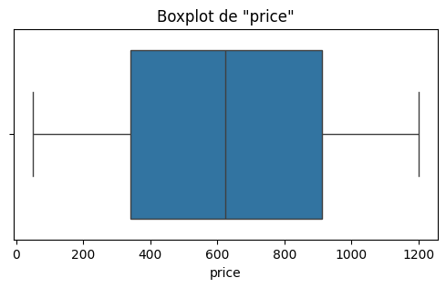

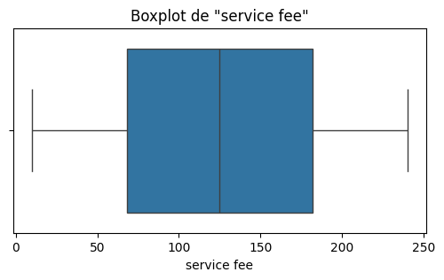

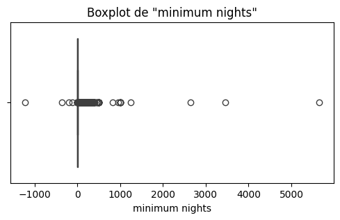

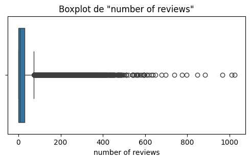

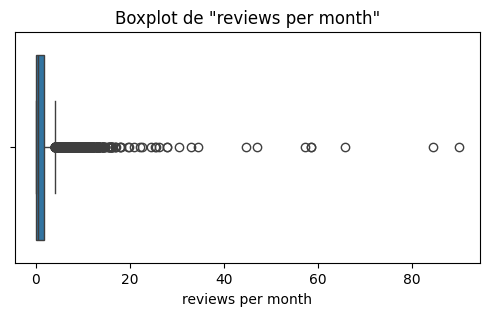

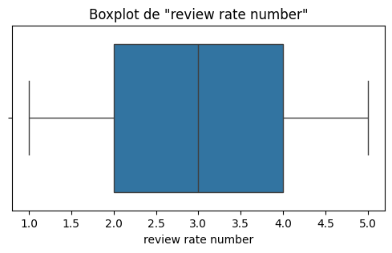

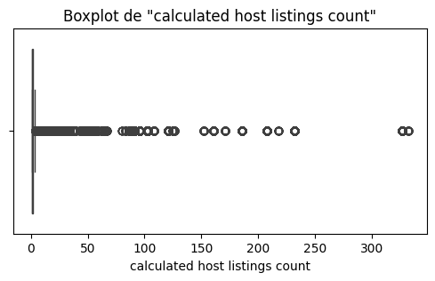

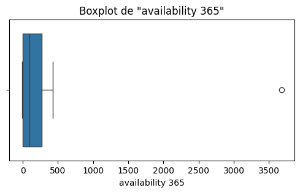

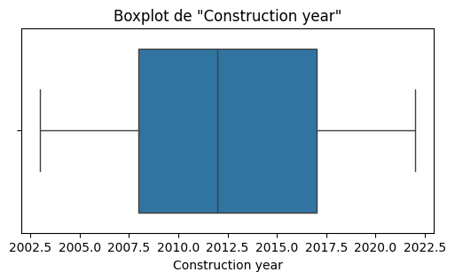

```python
cols_numericas = [
    'price', 'service fee', 'minimum nights', 'number of reviews',
    'reviews per month', 'review rate number', 'calculated host listings count',
    'availability 365', 'Construction year'
]

for col in cols_numericas:
    plt.figure(figsize=(6, 3))
    sns.boxplot(x=df[col])
    plt.title(f'Boxplot de "{col}"')
    plt.show()
```

## Identificación detallada.

Se utiliza el método del rango intercuartílico (IQR) para detectar valores atípicos:

```python
cols_numericas = [
    'price', 'service fee', 'minimum nights', 'number of reviews',
    'reviews per month', 'review rate number', 'calculated host listings count',
    'availability 365', 'Construction year', 'lat', 'long'
]

def detectar_outliers(df, columnas):
    resumen = []
    for col in columnas:
        Q1 = df[col].quantile(0.25)
        Q3 = df[col].quantile(0.75)
        IQR = Q3 - Q1
        limite_inferior = Q1 - 1.5 * IQR
        limite_superior = Q3 + 1.5 * IQR

        outliers = df[(df[col] < limite_inferior) | (df[col] > limite_superior)]
        total_outliers = outliers.shape[0]
        porcentaje = (total_outliers / len(df)) * 100

        resumen.append({
            'Columna': col,
            'Outliers': total_outliers,
            'Porcentaje': round(porcentaje, 2),
            'Min': df[col].min(),
            'Max': df[col].max(),
            'Límite Inferior': limite_inferior,
            'Límite Superior': limite_superior
        })

    return pd.DataFrame(resumen)

df_outliers = detectar_outliers(df, cols_numericas)
df_outliers
```

|  | Columna | Outliers | Porcentaje | Min | Max | Límite Inferior | Límite Superior |
| --- | --- | --- | --- | --- | --- | --- | --- |
| 0 | price | 0 | 0.00 | 50.00000 | 1200.00000 | -515.500000 | 1768.500000 |
| 1 | service fee | 0 | 0.00 | 10.00000 | 240.00000 | -103.000000 | 353.000000 |
| 2 | minimum nights | 18394 | 17.93 | -1223.00000 | 5645.00000 | -2.500000 | 9.500000 |
| 3 | number of reviews | 11736 | 11.44 | 0.00000 | 1024.00000 | -42.500000 | 73.500000 |
| 4 | reviews per month | 5747 | 5.60 | 0.00000 | 90.00000 | -2.340000 | 4.140000 |
| 5 | review rate number | 0 | 0.00 | 1.00000 | 5.00000 | -1.000000 | 7.000000 |
| 6 | calculated host listings count | 17829 | 17.38 | 1.00000 | 332.00000 | -0.500000 | 3.500000 |
| 7 | availability 365 | 1 | 0.00 | -10.00000 | 3677.00000 | -394.500000 | 665.500000 |
| 8 | Construction year | 0 | 0.00 | 2003.00000 | 2022.00000 | 1994.500000 | 2030.500000 |
| 9 | lat | 916 | 0.89 | 40.49979 | 40.91697 | 40.577710 | 40.873790 |
| 10 | long | 6539 | 6.37 | -74.24984 | -73.70522 | -74.057925 | -73.857005 |

## Análisis de Outliers

A partir del análisis estadístico mediante el método IQR, se pueden inferir las siguientes observaciones:

## Tratamiento de Ouliers

### Eliminación de errores claros.

`minimum nights` y `availability` - No pueden ser negativos.

```python
# 1. CORRECCIÓN DE ERRORES CLAROS.

# Eliminación de valores negativos
df = df[df['minimum nights'] >= 0]
df = df[df['availability 365'] >= 0]
```

### Filtración de rangos válidos (NYC)

`lat` y `long` - Se límitan a la zona de NYC

```python
# Limitación geográfica a NYC
df = df[(df['lat'] >= 40.5) & (df['lat'] <= 40.92)]
df = df[(df['long'] >= -74.25) & (df['long'] <= -73.70)]
```

### Recorte de Outliers con IQR.

Recorte de valores extremos para columnas numéricas.

```python
# 2. RECORTE DE OUTLIERS CON IQR

# Columnas numéricas
cols_num = [
    'minimum nights', 'number of reviews', 'reviews per month',
    'calculated host listings count', 'availability 365', 'lat', 'long'
]

# Función de recorte (winsorizing)
def recortar_outliers(df, columnas):
    for col in columnas:
        Q1 = df[col].quantile(0.25)
        Q3 = df[col].quantile(0.75)
        IQR = Q3 - Q1
        limite_inferior = Q1 - 1.5 * IQR
        limite_superior = Q3 + 1.5 * IQR
        df[col] = df[col].clip(lower=limite_inferior, upper=limite_superior)
    return df

df = recortar_outliers(df, cols_num)
```

```python
# Columnas monetarias a recortar
cols_monetarias = ['price', 'service fee']
df = recortar_outliers(df, cols_monetarias)
```

### Transformación Logarítmica

Algunas variables numéricas presentan un **sesgo positivo** y valores muy dispersos (outliers), lo que puede afectar tanto el análisis exploratorio como el desempeño de modelos predictivos.  
Para corregir esto, aplicamos la **transformación logarítmica** a las siguientes columnas:

- `minimum nights`
- `number of reviews`
- `reviews per month`
- `calculated host listings count`
- `price`
- `service fee`

Se utilizó `np.log1p()` en lugar de `np.log()` para evitar problemas con valores cero:

```python
# 3. TRANSFORMACIÓN LOGARITMICA

# Variables con sesgo positivo
cols_log = [
    'minimum nights', 'number of reviews', 'reviews per month',
    'calculated host listings count', 'price', 'service fee'
]

for col in cols_log:
    df[col + '_log'] = np.log1p(df[col])  # np.log1p para evitar log(0)
```

### Escalado de Variables

Después de aplicar la **transformación logarítmica**, algunas variables siguen teniendo rangos muy distintos entre sí.  
Para que los modelos funcionen correctamente aplicamos un **escalado estándar** (`StandardScaler`) a las siguientes columnas:

- `minimum nights_log`
- `number of reviews_log`
- `reviews per month_log`
- `calculated host listings count_log`
- `price_log`
- `service fee_log`
- `availability 365`
- `review rate number`

```python
# 4. ESCALADO DE VARIABLES

cols_scaler = [
    'minimum nights_log', 'number of reviews_log', 'reviews per month_log',
    'calculated host listings count_log', 'price_log', 'service fee_log',
    'availability 365', 'review rate number'
]

scaler = StandardScaler()
df[cols_scaler] = scaler.fit_transform(df[cols_scaler])
```

### Comprobación del tratamiento de Outliers

```python
df_outliers = detectar_outliers(df, cols_numericas)
df_outliers
```

|  | Columna | Outliers | Porcentaje | Min | Max | Límite Inferior | Límite Superior |
| --- | --- | --- | --- | --- | --- | --- | --- |
| 0 | price | 0 | 0.0 | 50.000000 | 1200.000000 | -515.500000 | 1768.500000 |
| 1 | service fee | 0 | 0.0 | 10.000000 | 240.000000 | -103.000000 | 353.000000 |
| 2 | minimum nights | 0 | 0.0 | 1.000000 | 9.500000 | -2.500000 | 9.500000 |
| 3 | number of reviews | 0 | 0.0 | 0.000000 | 73.500000 | -42.500000 | 73.500000 |
| 4 | reviews per month | 0 | 0.0 | 0.000000 | 4.140000 | -2.340000 | 4.140000 |
| 5 | review rate number | 0 | 0.0 | -1.778339 | 1.342248 | -3.338632 | 2.902542 |
| 6 | calculated host listings count | 0 | 0.0 | 1.000000 | 3.500000 | -0.500000 | 3.500000 |
| 7 | availability 365 | 0 | 0.0 | -1.050876 | 3.897989 | -3.972675 | 3.897989 |
| 8 | Construction year | 0 | 0.0 | 2003.000000 | 2022.000000 | 1994.500000 | 2030.500000 |
| 9 | lat | 0 | 0.0 | 40.577700 | 40.873780 | 40.577700 | 40.873780 |
| 10 | long | 0 | 0.0 | -74.057895 | -73.856975 | -74.057895 | -73.856975 |

# 2. Análisis exploratorio con visualizaciones.

## Comparación de precios por tipo de alojamiento.

```python
df[['room type', 'price']].head()
df.groupby('room type')['price'].describe()
```

| room type | count | mean | std | min | 25% | 50% | 75% | max |
| --- | --- | --- | --- | --- | --- | --- | --- | --- |
| Entire home/apt | 53450.0 | 625.280187 | 331.274609 | 50.0 | 341.0 | 624.0 | 913.00 | 1200.0 |
| Hotel room | 116.0 | 668.465517 | 310.866487 | 50.0 | 424.0 | 644.5 | 937.25 | 1193.0 |
| Private room | 46369.0 | 625.015657 | 330.974079 | 50.0 | 341.0 | 623.0 | 910.00 | 1200.0 |
| Shared room | 2218.0 | 633.472949 | 337.879140 | 50.0 | 325.0 | 651.0 | 925.00 | 1199.0 |

1. Precio promedio similar entre `Entire home/apt` y `Private room` (~625 USD), con rangos intercuartílicos parecidos.
2. `Hotel room` presenta un precio promedio ligeramente mayor (~668 USD), aunque la muestra es muy pequeña (116 registros), por lo que puede no ser representativa.
3. `Shared room` tiene un precio promedio intermedio (~633 USD), pero también con una distribución amplia.

## Mapa de calor y correlación de variables.

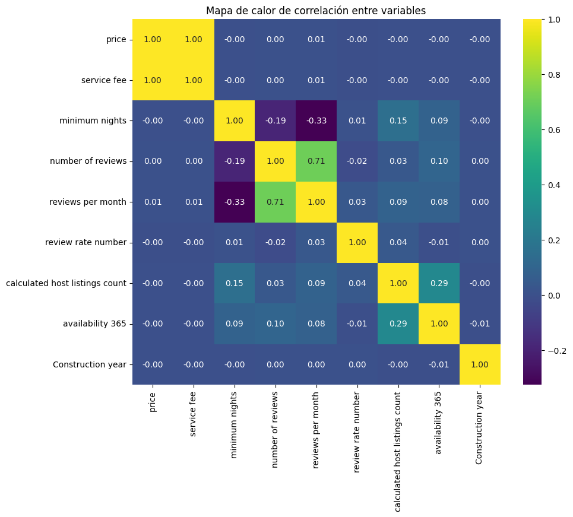

```python
numericas = [
    'price', 'service fee', 'minimum nights', 'number of reviews',
    'reviews per month', 'review rate number', 'calculated host listings count',
    'availability 365', 'Construction year'
]
df_num = df[numericas]

corr_matrix = df_num.corr()
corr_matrix

plt.figure(figsize=(10,8))
sns.heatmap(corr_matrix, annot=True, fmt=".2f", cmap='viridis')
plt.title('Mapa de calor de correlación entre variables')
plt.show()
```

- **Precio y Service Fee:** Correlación positiva alta, indicando que propiedades más caras tienden a tener mayores tarifas de servicio.
- **Número de reviews y reviews per month:** Correlación moderada, refleja la actividad de los huéspedes, pero no impacta directamente el precio.
- **Availability 365 y Construction Year:** Correlación baja con el precio, lo que indica que estas variables influyen poco en el costo final.
- **Otras variables:** La mayoría de las correlaciones son bajas, lo que sugiere que cada variable aporta información distinta y puede ser relevante en combinación con otras para el modelo predictivo.

Clasificación manual de los alojamientos según su precio, utilizando los siguientes rangos:

- `Económico`: 0 – 100 USD
- `Medio`: 101 – 300 USD
- `Alto`: 301 – 1000 USD
- `Premium`: 1001 USD en adelante

```python
# Usando rangos manuales
bins = [0, 100, 300, 1000, df['price'].max()]
labels = ['Económico', 'Medio', 'Alto', 'Premium']

df['price_range'] = pd.cut(df['price'], bins=bins, labels=labels)
df[['price', 'price_range']].head()
```

|  | price | price_range |
| --- | --- | --- |
| 0 | 966.0 | Alto |
| 1 | 142.0 | Medio |
| 2 | 620.0 | Alto |
| 3 | 368.0 | Alto |
| 4 | 204.0 | Medio |

## Segmentación de alojamientos por rangos de precio y ubicación

Se realizó un **agrupamiento por zona (`neighbourhood group`) y rango de precio (`price_range`)** para analizar la distribución de los alojamientos en Nueva York:

```python
segmentacion = df.groupby(['neighbourhood group', 'price_range'], observed=True).size().unstack()
segmentacion
```

| price_range neighbourhood group | Económico | Medio | Alto | Premium |
| --- | --- | --- | --- | --- |
| Bronx | 97 | 439 | 1711 | 455 |
| Brooklyn | 1834 | 7123 | 25457 | 7252 |
| Manhattan | 1953 | 7606 | 26601 | 7453 |
| Queens | 532 | 2300 | 7983 | 2410 |
| Staten Island | 46 | 149 | 597 | 155 |

- **Heatmap:** facilita identificar zonas con alta concentración de precios específicos.

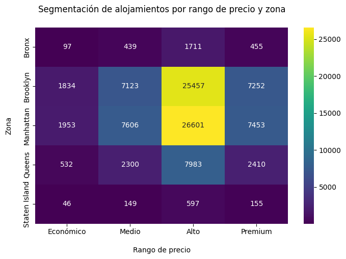

```python
plt.figure(figsize=(8,5))
sns.heatmap(segmentacion, annot=True, fmt="g", cmap='viridis')
plt.title('Segmentación de alojamientos por rango de precio y zona\n')
plt.ylabel('Zona\n')
plt.xlabel('\nRango de precio')
plt.show()
```

## Visualizaciones relevantes:

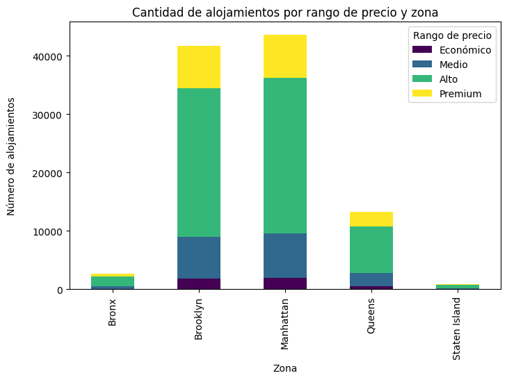

```python
segmentacion.plot(kind='bar', stacked=True, figsize=(8,5), colormap='viridis')
plt.title('Cantidad de alojamientos por rango de precio y zona')
plt.ylabel('Número de alojamientos\n')
plt.xlabel('Zona')
plt.legend(title='Rango de precio')
plt.show()
```

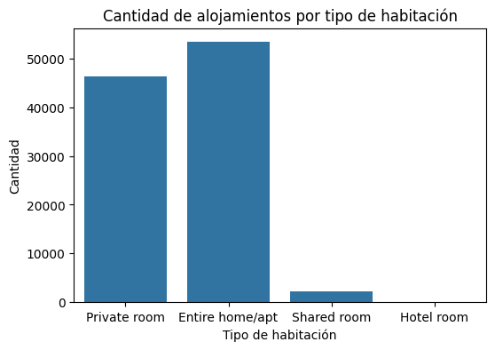

```python
plt.figure(figsize=(6,4))
sns.countplot(x='room type', data=df)
plt.title('Cantidad de alojamientos por tipo de habitación')
plt.xlabel('Tipo de habitación')
plt.ylabel('Cantidad')
plt.show()
```

```python
conteo = df['room type'].value_counts()
conteo
```

```
room type
Entire home/apt    53450
Private room       46369
Shared room         2218
Hotel room           116
Name: count, dtype: int64
```

La mayoría de los alojamientos corresponden a Entire home/apt y Private room, mientras que Hotel room y Shared room son minoritarios.

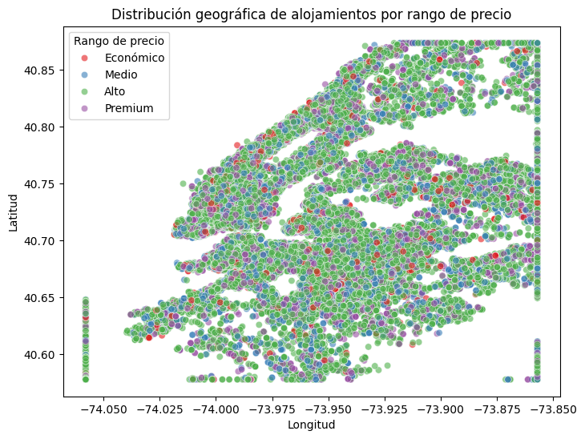

```python
plt.figure(figsize=(8,6))
sns.scatterplot(x='long', y='lat', hue='price_range', data=df, palette='Set1', alpha=0.6)
plt.title('Distribución geográfica de alojamientos por rango de precio')
plt.xlabel('Longitud')
plt.ylabel('Latitud')
plt.legend(title='Rango de precio')
plt.show()
```

# 3. Modelo de predicción de precios

- **minimum nights_log:** Influye en el precio según la duración mínima de la reserva.
- **number of reviews_log / reviews per month_log:** Reflejan popularidad y demanda.
- **calculated host listings count_log:** Estrategia del anfitrión; más propiedades pueden afectar precios.
- **service fee_log:** Directamente relacionada con el precio final.
- **availability 365:** Propiedades más disponibles pueden tener precios distintos.
- **review rate number:** Mejor reputación puede justificar precios más altos.

```python
# Variables predictoras
X = df[[
    'minimum nights_log', 'number of reviews_log', 'reviews per month_log',
    'calculated host listings count_log', 'service fee_log',
    'availability 365', 'review rate number'
]]

# Variable objetivo
y = df['price_log']
```

- **Entrenamiento (80%)**: `X_train`, `y_train` → se usan para ajustar el modelo.
- **Prueba (20%)**: `X_test`, `y_test` → se usan para evaluar el desempeño del modelo en datos no vistos.

```python
X_train, X_test, y_train, y_test = train_test_split(
    X, y, test_size=0.2, random_state=42
)
```

1. **Entrenamiento:**
   - Se creó un modelo de **Regresión Lineal** (`LinearRegression`) y se ajustó usando los datos de entrenamiento (`X_train`, `y_train`).
2. **Predicción:**
   - El modelo predice los precios log-transformados en el conjunto de prueba (`X_test`), generando `y_pred_lr`.
3. **Evaluación:**
   - **RMSE (Root Mean Squared Error):** error promedio cuadrático de las predicciones.
   - **MAE (Mean Absolute Error):** error absoluto promedio.
   - **R² (Coeficiente de determinación):** porcentaje de variabilidad del precio log explicado por el modelo.

```python
# Entrenamiento
lr = LinearRegression()
lr.fit(X_train, y_train)

# Predicción
y_pred_lr = lr.predict(X_test)

# Evaluación
print("Linear Regression")
rmse = mean_squared_error(y_test, y_pred_lr) ** 0.5
print("RMSE:", rmse)
print("MAE:", mean_absolute_error(y_test, y_pred_lr))
print("R2:", r2_score(y_test, y_pred_lr))
```

```
Linear Regression
RMSE: 0.06371334701841838
MAE: 0.008796242792044091
R2: 0.9959500342885662
```

- **RMSE:** 0.064 → error promedio cuadrático en escala log.
- **MAE:** 0.009 → error absoluto promedio muy bajo.
- **R²:** 0.996 → el modelo explica casi el 100% de la variabilidad del precio log-transformado.

> Conclusión: La regresión lineal predice de manera muy precisa los precios log-transformados de los alojamientos.

# 4. Conclusiones del análisis.

#### B. Variables que influyen en el precio

- Existe una correlación alta entre **service fee** y **price**, indicando que el precio final depende en gran medida de las tarifas de servicio.
- Variables como **número de reseñas** y **reviews per month** tienen correlación baja con el precio, lo que sugiere que la popularidad no determina significativamente el valor.
- **Disponibilidad 365** y **año de construcción** presentan correlaciones bajas, pero podrían influir en segmentos de mercado específicos.

#### D. Recomendaciones

1. **Estrategia de precios según zona:**
   - En Manhattan y Brooklyn, los alojamientos pueden mantener tarifas altas o Premium, enfocándose en viajeros dispuestos a pagar más por ubicación y comodidad.
   - En Bronx y Staten Island, se pueden ofrecer precios competitivos o promociones para atraer a clientes sensibles al costo.
   - En Queens, ajustar precios en rangos Medio-Alto según demanda y tipo de propiedad.
2. **Segmentación y marketing:**
   - Utilizar información de reseñas y actividad (`number of reviews`, `reviews per month`) para identificar propiedades populares y promocionarlas, aunque no influyan directamente en el precio.